# Praca domowa 5

Artur Minorczyk

Wykorzystane przeze mnie dane pochodzą z artykułu http://microeconomicinsights.org/star-scientists-choose-locate-impact-us-state-taxes/ i dotyczą wysokości podatków stanowych w USA. W artykule pojawiają się dwie mapy USA z podziałem na poszczególne stany. Kolor danego stanu uzależniony jest od wysokości obowiązującego w nim podatku.

Największym problemem wspomnianych wykresów jest użyta skala kolorów. Uniemożliwia ona proste porównanie wysokości podatku w dwóch stanach i wymaga nieustannego korzystania z legendy. W rezultacie wykres w łatwy sposób umożliwia jedynie zlokalizowanie stanów, w których podatek wynosi 0% (czerwone stany). Jednak zwykła lista stanów z zerowym podatkiem robiłaby to w równie dobry sposób, a nawet lepszy, gdyż nie wymagała znajomości geografii Stanów Zjednoczonych.

Dwoma mniejszymi, raczej kosmetycznymi problemami są zakres czerwonego koloru, który w legendzie opisany jest jako $[-1, 0]$, pomimo że ujemna wartość oczywiście nigdy nie zostanie przyjęta. Drugim problemem jest nieco mylący fakt, iż tylko niektóre stany mają podaną wartość liczbową obowiązującego w nich podatku. Po bliższym przyjrzeniu się wykresom można się domyślić, że wybrane zostały stany o zerowym podatku oraz trzy stany z najwyższym podatkiem.

Aby uzyskać lepszy wykres, wystarczy praktycznie tylko lepiej dobrać skalę kolorów oraz usunąć nieścisłości. W celu stworzenia takiego wykresu posłużono się danymi z portalu Wikipedia pochodzącymi z 2016r (https://en.wikipedia.org/wiki/State_income_tax), gdyż w samym artykule nie zamieszczono kompletu danych.

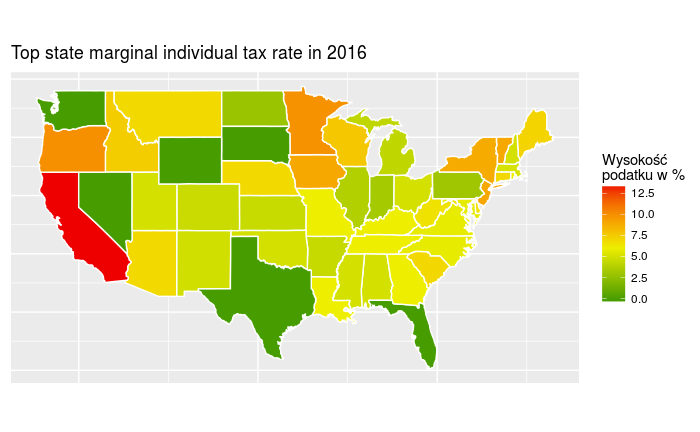

```r
ggplot(data = states_tax) +
  geom_polygon(aes(x = long, y = lat, fill = tax, group = group), color = "white") +
  scale_fill_gradient2(low = "green4", mid = "yellow2", high = "red2", midpoint = 6, name="Wysokość\npodatku w %") +
  coord_fixed(1.3) +
  ggtitle("Top state marginal individual tax rate in 2016") +
  theme(axis.title.x=element_blank(),
        axis.text.x=element_blank(),
        axis.ticks.x=element_blank(),
        axis.title.y=element_blank(),
        axis.text.y=element_blank(),
        axis.ticks.y=element_blank())
```